# 670 Project - Happiness in the Time of Covid

We found some interesting datasets on Kaggle - namely the World Happiness Reports from2015-2019, and 2021. They contain information like how GDP and life expectancy contributeto a “happiness rating” (based on the Gallup World Poll). We also have some COVID-19 datafor all countries which includes cases per day, deaths and cumulative counts over 2020.

The three Kaggle datasets we used are at the following URLS:

- https://www.kaggle.com/tunguz/data-on-covid19-coronavirus?select=owid-covid-data.csv
- https://www.kaggle.com/ajaypalsinghlo/world-happiness-report-2021
- https://www.kaggle.com/unsdsn/world-happiness

Load the libraries we need for the project:

```r
library(ggplot2)
library(tidyr)
library(dplyr)
library(gtools)
```

Load the datasets:

```r
happiness_2015 <- read.csv("data/2015.csv",header=T,na.strings="?")
happiness_2016 <- read.csv("data/2016.csv",header=T,na.strings="?")
happiness_2017 <- read.csv("data/2017.csv",header=T,na.strings="?")
happiness_2018 <- read.csv("data/2018.csv",header=T,na.strings="?")
happiness_2019 <- read.csv("data/2019.csv",header=T,na.strings="?")
happiness_2021 <- read.csv("data/world-happiness-report-2021.csv",header=T,na.strings="?")

covid2020_filtered <- read.csv("data/covid2020-filtered.csv", header = T, na.strings = "?")
```

# 1. Data Preprocessing

Manually, once we loaded in the data we noticed many column name mismatches and had to rename quite a few (for example, “Country” vs “Country or Region” or “Score” vs. “Happiness Score”). We started renaming the columns programatically but it was very tedious code to write and look at so we took it out of the notebook, we show how we changed the country column name just as an example.

##### Rename “Country.or.region” to “Country” in 2018/2019 so we can join with the rest.

```r
colnames(happiness_2018)[2] <- "Country"
names(happiness_2018)
```

```
## [1] "Happiness.Rank"            "Country"
## [3] "Happiness.Score"           "GDP.per.capita"
## [5] "Social.support"            "Healthy.life.expectancy"
## [7] "Freedom"                   "Generosity"
## [9] "Perceptions.of.corruption"
```

```r
colnames(happiness_2019)[2] <- "Country"
names(happiness_2019)
```

```
## [1] "Happiness.Rank"            "Country"
## [3] "Happiness.Score"           "GDP.per.capita"
## [5] "Social.support"            "Healthy.life.expectancy"
## [7] "Freedom"                   "Generosity"
## [9] "Perceptions.of.corruption"
```

```r
happiness_2015 = subset(happiness_2015, select=-c(Region,Standard.Error,Dystopia.Residual))
happiness_2016 = subset(happiness_2016,select=-c(Region,Lower.Confidence.Interval,Upper.Confidence.Interval,Dystopia.Residual))
happiness_2017 = subset(happiness_2017, select=-c(Whisker.high,Whisker.low,Dystopia.Residual))
```

##### Add a “Year” Column to each to keep track before merging.

```r
happiness_2015$Year=2015
happiness_2016$Year=2016
happiness_2017$Year=2017
happiness_2018$Year=2018
happiness_2019$Year=2019
```

##### Combine 2015-2019 happiness data into one dataframe

```r
happiness = smartbind(happiness_2015, happiness_2016, happiness_2017, happiness_2018, happiness_2019)
dim(happiness)
```

```
## [1] 781  11
```

```r
names(happiness)
```

```
##  [1] "Country"                   "Happiness.Rank"
##  [3] "Happiness.Score"           "GDP.per.capita"
##  [5] "Family"                    "Healthy.life.expectancy"
##  [7] "Freedom"                   "Perceptions.of.corruption"
##  [9] "Generosity"                "Year"
## [11] "Social.support"
```

#### Dataset Explanation:

- There are six factors – economic production(GDP per capita), social support, life expectancy(Healthy life expectancy), freedom, absence of corruption(Perceptions of corruption), and generosity – contributing to the calculation of the happiness score of each country.
- We filtered out the total COVID-19 cases and total COVID-19 deaths by December 31st, 2020 of each country.

### A little exploration of the data visually - what do happiness trends look like in the US and neighboring countries?

##### Happiness score of Canada, United States, and Mexico from 2015 to 2019.

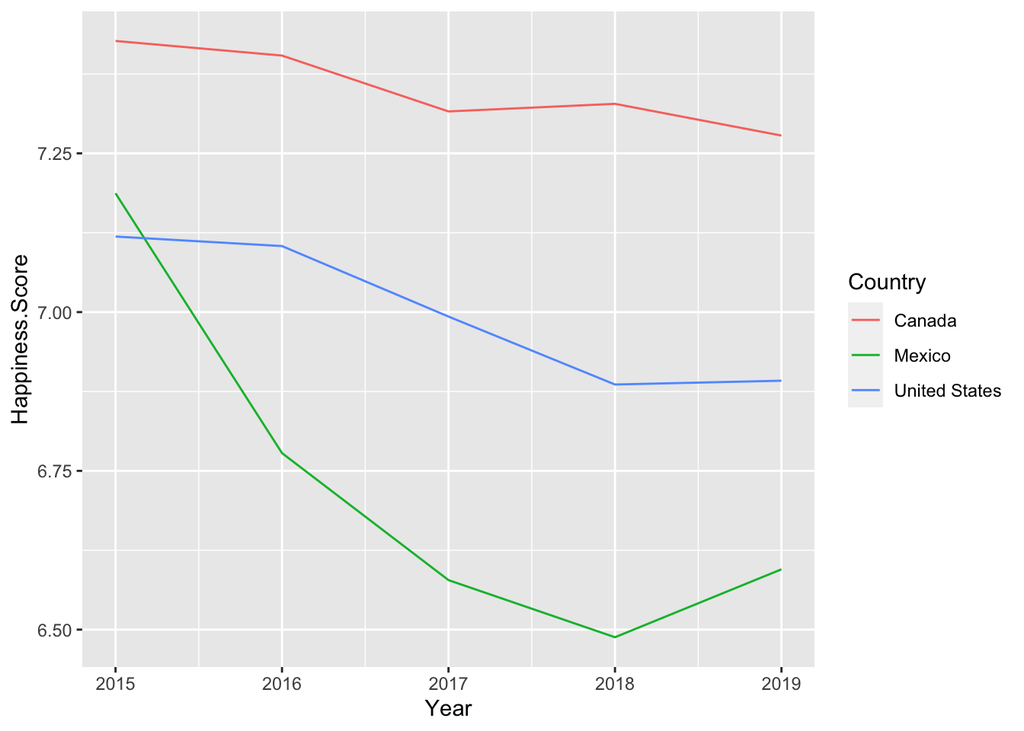

```r
happiness_na <- subset(happiness, Country == "Canada" | Country == "United States" | Country =="Mexico",
select=c(Country, Year, Happiness.Score, Happiness.Rank))
ggplot(happiness_na, aes(Year, Happiness.Score, group=Country)) + geom_line(aes(color=Country))
```

##### Happiness rank of Canada, United States, and Mexico from 2015 to 2019.

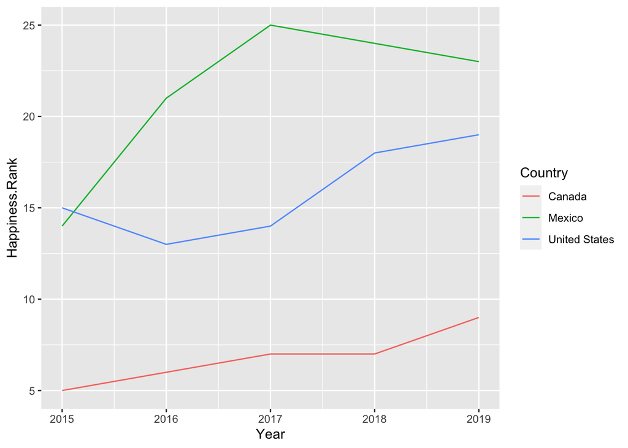

```r
ggplot(happiness_na, aes(Year, Happiness.Rank, group=Country)) + geom_line(aes(color=Country))
```

# 2. Models

### Models and Analysis on 2015-2019 Data (before COVID)

#### Q: What factors seem to contribute to a “happier” country?

##### Check linear statistical significance of all predictors in response to happiness score.

```r
lm.score.1 = lm(Happiness.Score~ GDP.per.capita + Social.support + Healthy.life.expectancy + Freedom + Generosity + Perceptions.of.corruption, data = happiness)
summary(lm.score.1)
```

```
##
## Call:
## lm(formula = Happiness.Score ~ GDP.per.capita + Social.support +
##     Healthy.life.expectancy + Freedom + Generosity + Perceptions.of.corruption,
##     data = happiness)
##
## Residuals:
##      Min       1Q   Median       3Q      Max
## -1.77659 -0.33082  0.03445  0.36840  1.19024
##
## Coefficients:
##                           Estimate Std. Error t value Pr(>|t|)
## (Intercept)                 1.8132     0.1422  12.752  < 2e-16 ***
## GDP.per.capita              0.8378     0.1552   5.399 1.35e-07 ***
## Social.support              1.1222     0.1558   7.204 4.64e-12 ***
## Healthy.life.expectancy     1.0133     0.2130   4.757 3.04e-06 ***
## Freedom                     1.4323     0.2336   6.132 2.69e-09 ***
## Generosity                  0.5035     0.3380   1.490   0.1373
## Perceptions.of.corruption   0.8495     0.3738   2.272   0.0238 *
## ---
## Signif. codes:  0 '***' 0.001 '**' 0.01 '*' 0.05 '.' 0.1 ' ' 1
##
## Residual standard error: 0.5219 on 304 degrees of freedom
##   (470 observations deleted due to missingness)
## Multiple R-squared:  0.7847, Adjusted R-squared:  0.7804
## F-statistic: 184.6 on 6 and 304 DF,  p-value: < 2.2e-16
```

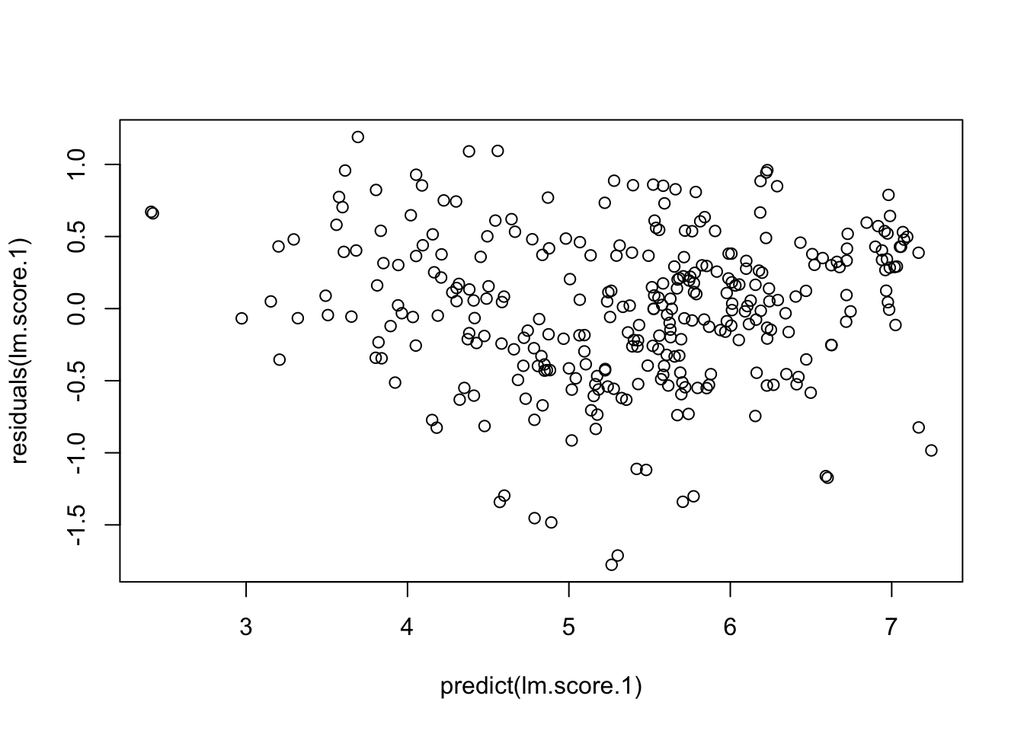

```r
# Plot predictions and residuals
plot(predict(lm.score.1), residuals(lm.score.1))
```

##### Check linear statistical significance of all predictors in response to happiness rank.

```r
lm.rank.1 = lm(Happiness.Rank~ GDP.per.capita + Social.support + Healthy.life.expectancy + Freedom + Generosity + Perceptions.of.corruption, data = happiness)
summary(lm.rank.1)
```

```
##
## Call:
## lm(formula = Happiness.Rank ~ GDP.per.capita + Social.support +
##     Healthy.life.expectancy + Freedom + Generosity + Perceptions.of.corruption,
##     data = happiness)
##
## Residuals:
##     Min      1Q  Median      3Q     Max
## -44.909 -13.931  -2.229  15.728  66.871
##
## Coefficients:
##                           Estimate Std. Error t value Pr(>|t|)
## (Intercept)                218.791      5.908  37.035  < 2e-16 ***
## GDP.per.capita             -37.801      6.447  -5.864 1.18e-08 ***
## Social.support             -40.573      6.472  -6.269 1.25e-09 ***
## Healthy.life.expectancy    -41.574      8.850  -4.698 3.99e-06 ***
## Freedom                    -60.341      9.704  -6.218 1.66e-09 ***
## Generosity                 -11.365     14.042  -0.809    0.419
## Perceptions.of.corruption  -17.485     15.532  -1.126    0.261
## ---
## Signif. codes:  0 '***' 0.001 '**' 0.01 '*' 0.05 '.' 0.1 ' ' 1
##
## Residual standard error: 21.68 on 304 degrees of freedom
##   (470 observations deleted due to missingness)
## Multiple R-squared:  0.7729, Adjusted R-squared:  0.7684
## F-statistic: 172.4 on 6 and 304 DF,  p-value: < 2.2e-16
```

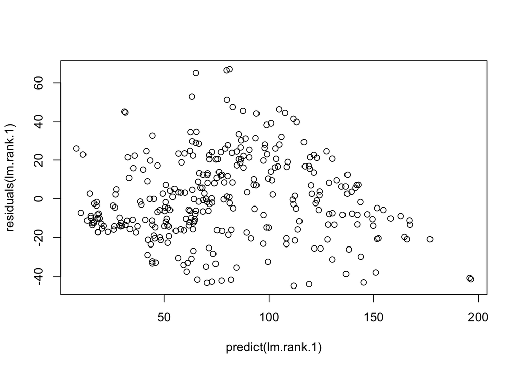

```r
# Plot predictions and residuals
plot(predict(lm.rank.1), residuals(lm.rank.1))
```

##### Fit a linear model with significant predictors in response to happiness score.

```r
lm.score.2 = lm(Happiness.Score~ GDP.per.capita + Healthy.life.expectancy + Freedom, data = happiness)
summary(lm.score.2)
```

```
##
## Call:
## lm(formula = Happiness.Score ~ GDP.per.capita + Healthy.life.expectancy +
##     Freedom, data = happiness)
##
## Residuals:
##      Min       1Q   Median       3Q      Max
## -2.06450 -0.38652  0.02477  0.40118  1.53266
##
## Coefficients:
##                         Estimate Std. Error t value Pr(>|t|)
## (Intercept)              2.52366    0.06852  36.834   <2e-16 ***
## GDP.per.capita           1.33093    0.08345  15.949   <2e-16 ***
## Healthy.life.expectancy  1.19815    0.13592   8.815   <2e-16 ***
## Freedom                  2.19503    0.14498  15.140   <2e-16 ***
## ---
## Signif. codes:  0 '***' 0.001 '**' 0.01 '*' 0.05 '.' 0.1 ' ' 1
##
## Residual standard error: 0.5768 on 777 degrees of freedom
## Multiple R-squared:  0.7391, Adjusted R-squared:  0.7381
## F-statistic: 733.6 on 3 and 777 DF,  p-value: < 2.2e-16
```

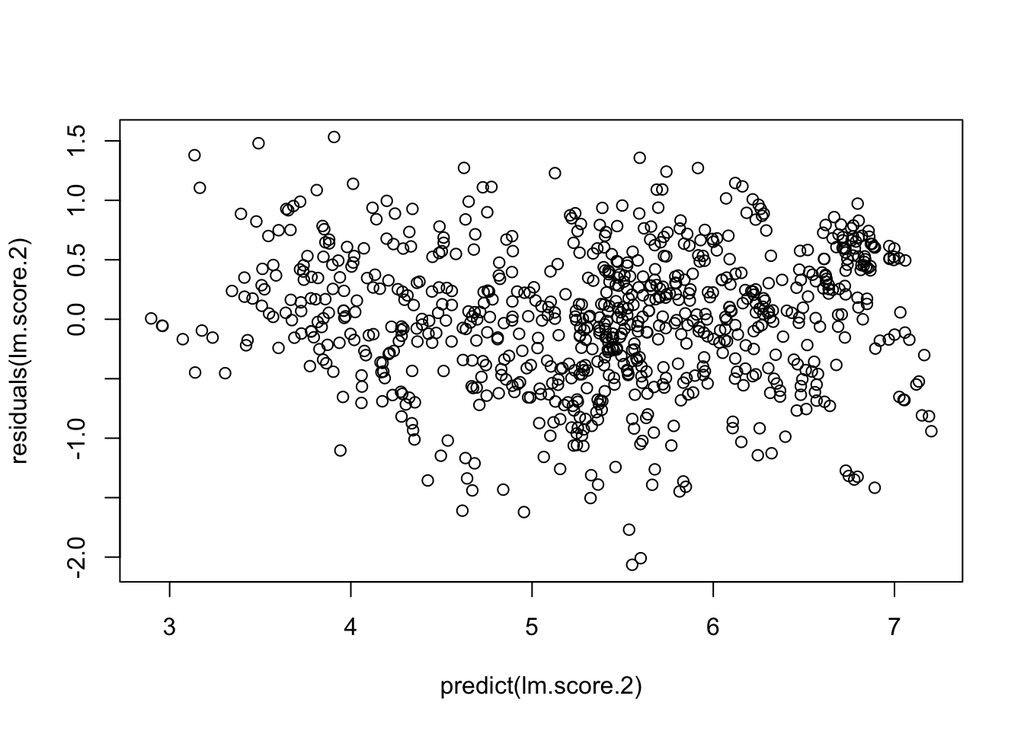

```r
# Plot predictions and residuals
plot(predict(lm.score.2), residuals(lm.score.2))
```

##### Fit a linear model with significant predictors in response to happiness rank.

```r
lm.rank.2 = lm(Happiness.Rank~ GDP.per.capita + Healthy.life.expectancy + Freedom, data = happiness)
summary(lm.rank.2)
```

```
##
## Call:
## lm(formula = Happiness.Rank ~ GDP.per.capita + Healthy.life.expectancy +
##     Freedom, data = happiness)
##
## Residuals:
##     Min      1Q  Median      3Q     Max
## -63.536 -15.566  -2.758  15.931  76.310
##
## Coefficients:
##                         Estimate Std. Error t value Pr(>|t|)
## (Intercept)              192.072      2.755  69.727   <2e-16 ***
## GDP.per.capita           -55.001      3.355 -16.394   <2e-16 ***
## Healthy.life.expectancy  -47.131      5.465  -8.625   <2e-16 ***
## Freedom                  -83.011      5.829 -14.241   <2e-16 ***
## ---
## Signif. codes:  0 '***' 0.001 '**' 0.01 '*' 0.05 '.' 0.1 ' ' 1
##
## Residual standard error: 23.19 on 777 degrees of freedom
## Multiple R-squared:  0.7373, Adjusted R-squared:  0.7363
## F-statistic:   727 on 3 and 777 DF,  p-value: < 2.2e-16
```

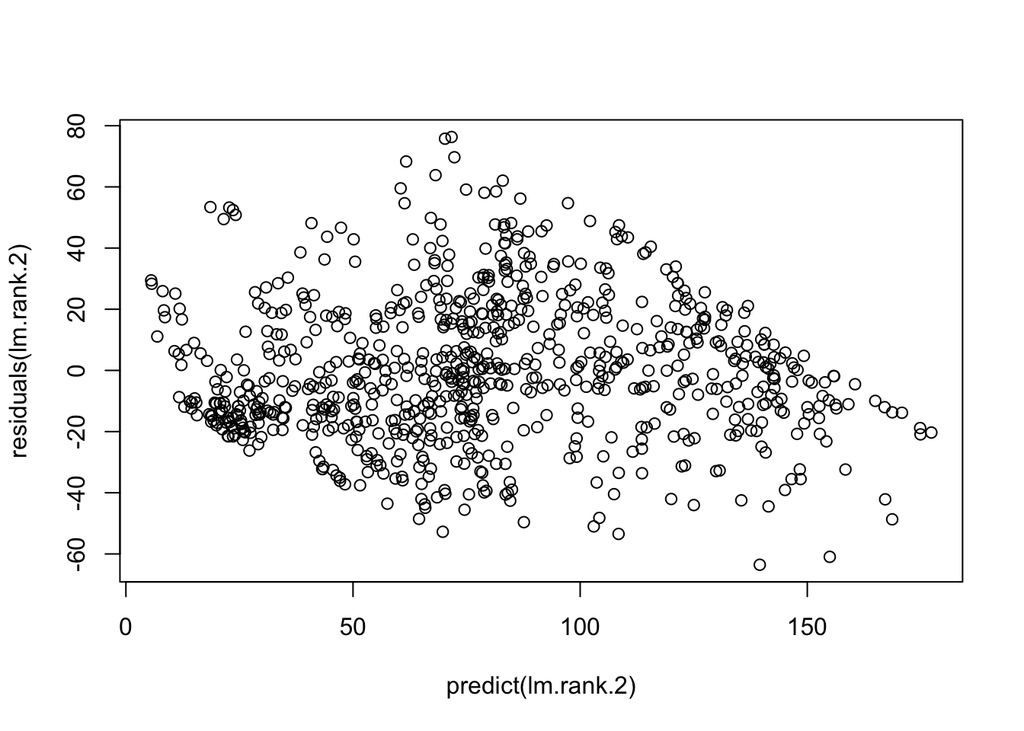

```r
# Plot predictions and residuals
plot(predict(lm.rank.2), residuals(lm.rank.2))
```

#### Results of linear models:

- GDP per capita, Healthy life expectancy, Social support and Freedom seem to contribute the most to a “happier” country.
- Generosity and Perceptions of corruption are the least significant predictors.
- However, Social support has been removed as not all previous data include such information.
- The plot of the rank models are the opposite of the score models.
- By removing generosity and perceptions of corruption, we get similar R-squared values but a higher F-statistics.

##### Fit a linear model with GDP.per.capita in response to happiness score using K-fold cross validation.

```r
library(boot)
set.seed(1)
cv.error.10 = rep(0:10)
glm.score = glm(Happiness.Score~GDP.per.capita, data = happiness)
cv.error.10 =cv.glm(happiness, glm.score, K=10)
cv.error.10$delta
```

```
## [1] 0.4792199 0.4791264
```

##### Fit a linear model with Healthy life expectancy in response to happiness score using K-fold cross validation.

```r
glm.score.life = glm(Happiness.Score~Healthy.life.expectancy, data = happiness)
cv.error.10.life =cv.glm(happiness, glm.score.life, K=10)
cv.error.10.life$delta
```

```
## [1] 0.5709074 0.5707854
```

##### Fit a linear model with Freedom in response to happiness score using K-fold cross validation.

```r
glm.score.free = glm(Happiness.Score~Freedom, data = happiness)
cv.error.10.free =cv.glm(happiness, glm.score.free, K=10)
cv.error.10.free$delta
```

```
## [1] 0.8822053 0.8820986
```

#### Fun facts about the 1-1 relationships:

- When we look at these variables on their own, the GDP per capita seems to be the best predictor of the happiness score, then healthy life expectancy, then freedom.
- We’ll try using all of the predictors to see if we can get improvement.

##### Fit a linear model with multiple predictors in response to happiness score using K-fold cross validation.

```r
glm.score.multi = glm(Happiness.Score ~ GDP.per.capita +  Healthy.life.expectancy + Freedom, data = happiness)
cv.error.10.multi =cv.glm(happiness, glm.score.multi, K=10)
cv.error.10.multi$delta
```

```
## [1] 0.3324874 0.3324112
```

#### The cross validation error improved!

### Models and Predictions for 2021, once COVID-19 was a thing.

#### Q: Does the impact of COVID-19 seem to have an effect on the happiness rating?

##### Merge happiness 2021 table with covid 2020 table using inner join.

```r
happy.covid <- happiness_2021 %>% inner_join(covid2020_filtered, by = c("Country.name" = "location"))

# statistics
summary(happy.covid[, c("Ladder.score", "Logged.GDP.per.capita", "Healthy.life.expectancy", "Freedom.to.make.life.choices", "total_cases", "total_deaths")])
```

```
##   Ladder.score   Logged.GDP.per.capita Healthy.life.expectancy
##  Min.   :2.523   Min.   : 6.635        Min.   :48.48
##  1st Qu.:4.848   1st Qu.: 8.540        1st Qu.:59.92
##  Median :5.563   Median : 9.563        Median :66.65
##  Mean   :5.538   Mean   : 9.418        Mean   :65.06
##  3rd Qu.:6.269   3rd Qu.:10.372        3rd Qu.:69.52
##  Max.   :7.842   Max.   :11.647        Max.   :76.95
##
##  Freedom.to.make.life.choices  total_cases        total_deaths
##  Min.   :0.3820               Min.   :      41   Min.   :     1.0
##  1st Qu.:0.7228               1st Qu.:   16987   1st Qu.:   239.8
##  Median :0.8105               Median :  109458   Median :  1733.0
##  Mean   :0.7942               Mean   :  587212   Mean   : 13078.2
##  3rd Qu.:0.8825               3rd Qu.:  343646   3rd Qu.:  7516.2
##  Max.   :0.9700               Max.   :20099363   Max.   :352093.0
##                                                  NA's   :2
```

##### Fit a linear model with happiness 2021 data only featuring significant predictors in response to happiness score.

```r
lm.score.wo.covid = lm(Ladder.score ~ Logged.GDP.per.capita + Social.support + Healthy.life.expectancy+ Freedom.to.make.life.choices + Generosity + Perceptions.of.corruption, data=happy.covid)
summary(lm.score.wo.covid)
```

```
##
## Call:
## lm(formula = Ladder.score ~ Logged.GDP.per.capita + Social.support +
##     Healthy.life.expectancy + Freedom.to.make.life.choices +
##     Generosity + Perceptions.of.corruption, data = happy.covid)
##
## Residuals:
##      Min       1Q   Median       3Q      Max
## -1.71470 -0.26124  0.06194  0.32693  1.17559
##
## Coefficients:
##                              Estimate Std. Error t value Pr(>|t|)
## (Intercept)                  -2.49146    0.63723  -3.910 0.000147 ***
## Logged.GDP.per.capita         0.24746    0.08780   2.818 0.005563 **
## Social.support                2.76440    0.66660   4.147 5.97e-05 ***
## Healthy.life.expectancy       0.03911    0.01417   2.761 0.006583 **
## Freedom.to.make.life.choices  1.73396    0.48670   3.563 0.000510 ***
## Generosity                    0.59977    0.31865   1.882 0.061991 .
## Perceptions.of.corruption    -0.64204    0.28497  -2.253 0.025894 *
## ---
## Signif. codes:  0 '***' 0.001 '**' 0.01 '*' 0.05 '.' 0.1 ' ' 1
##
## Residual standard error: 0.5198 on 133 degrees of freedom
## Multiple R-squared:  0.7818, Adjusted R-squared:  0.7719
## F-statistic: 79.41 on 6 and 133 DF,  p-value: < 2.2e-16
```

##### Fit a linear model with both happiness and covid data with significant predictors in response to happiness score.

```r
lm.score.w.covid = lm(Ladder.score ~ Logged.GDP.per.capita + Social.support + Healthy.life.expectancy+ Freedom.to.make.life.choices + Generosity + Perceptions.of.corruption + total_cases + total_deaths, data=happy.covid)
summary(lm.score.w.covid)
```

```
##
## Call:
## lm(formula = Ladder.score ~ Logged.GDP.per.capita + Social.support +
##     Healthy.life.expectancy + Freedom.to.make.life.choices +
##     Generosity + Perceptions.of.corruption + total_cases + total_deaths,
##     data = happy.covid)
##
## Residuals:
##      Min       1Q   Median       3Q      Max
## -1.72337 -0.23617  0.03169  0.32517  1.13909
##
## Coefficients:
##                                Estimate Std. Error t value Pr(>|t|)
## (Intercept)                  -2.337e+00  6.451e-01  -3.622 0.000419 ***
## Logged.GDP.per.capita         2.506e-01  9.015e-02   2.780 0.006254 **
## Social.support                2.697e+00  6.696e-01   4.028 9.54e-05 ***
## Healthy.life.expectancy       3.543e-02  1.438e-02   2.463 0.015088 *
## Freedom.to.make.life.choices  1.880e+00  4.987e-01   3.771 0.000247 ***
## Generosity                    6.031e-01  3.193e-01   1.889 0.061153 .
## Perceptions.of.corruption    -6.724e-01  2.872e-01  -2.342 0.020731 *
## total_cases                  -1.259e-07  7.263e-08  -1.734 0.085367 .
## total_deaths                  7.350e-06  3.793e-06   1.938 0.054816 .
## ---
## Signif. codes:  0 '***' 0.001 '**' 0.01 '*' 0.05 '.' 0.1 ' ' 1
##
## Residual standard error: 0.5182 on 129 degrees of freedom
##   (2 observations deleted due to missingness)
## Multiple R-squared:  0.7887, Adjusted R-squared:  0.7756
## F-statistic: 60.19 on 8 and 129 DF,  p-value: < 2.2e-16
```

#### Results from the above two models:

- Total covid cases and total deaths don’t seem to affect the happiness (Ladder) score much.

##### Predict happiness scores of 2021 using the models trained on previous years’ data.

```r
# prepare test data
data.2021 <- data.frame(GDP.per.capita=happy.covid$Logged.GDP.per.capita,Healthy.life.expectancy = happy.covid$Healthy.life.expectancy, Freedom=happy.covid$Freedom.to.make.life.choices)
lm.pred.score = predict(lm.score.2, data.2021) # without cross validation
glm.pred.score = predict(glm.score.multi, data.2021) # with cross validation

# append pred score to the dataframe
happy.covid$lm.pred.score = lm.pred.score
happy.covid$glm.pred.score = glm.pred.score

# pred statistics
summary(happy.covid[, c('lm.pred.score', 'glm.pred.score')])
```

```
##  lm.pred.score    glm.pred.score
##  Min.   : 71.68   Min.   : 71.68
##  1st Qu.: 88.23   1st Qu.: 88.23
##  Median : 96.67   Median : 96.67
##  Mean   : 94.76   Mean   : 94.76
##  3rd Qu.:101.05   3rd Qu.:101.05
##  Max.   :112.05   Max.   :112.05
```

##### Predicted rank per linear model without cv

```r
lm.pred.country.score <- happy.covid[, c("Country.name", "lm.pred.score")]
lm.pred.rank = lm.pred.country.score[order(-lm.pred.score),]
lm.pred.rank
```

|  | Country.name | lm.pred.score |
| --- | --- | --- |
| 30 | Singapore | 112.04899 |
| 3 | Switzerland | 108.47879 |
| 54 | Japan | 108.37405 |
| 25 | Spain | 107.76473 |
| 11 | Australia | 107.44151 |
| 14 | Canada | 107.29727 |
| 20 | France | 107.23694 |
| 6 | Norway | 107.16564 |
| 8 | Luxembourg | 107.00118 |
| 10 | Austria | 106.85586 |

[output cut: 130 more lines]

##### Predicted rank per glm model with cv

```r
glm.pred.country.score <- happy.covid[, c("Country.name", "glm.pred.score")]
glm.pred.rank = glm.pred.country.score[order(-glm.pred.score),]
glm.pred.rank
```

|  | Country.name | glm.pred.score |
| --- | --- | --- |
| 30 | Singapore | 112.04899 |
| 3 | Switzerland | 108.47879 |
| 54 | Japan | 108.37405 |
| 25 | Spain | 107.76473 |
| 11 | Australia | 107.44151 |
| 14 | Canada | 107.29727 |
| 20 | France | 107.23694 |
| 6 | Norway | 107.16564 |
| 8 | Luxembourg | 107.00118 |
| 10 | Austria | 106.85586 |

[output cut: 130 more lines]

### Plot Predicted vs. Actual for top 15 happiest countries

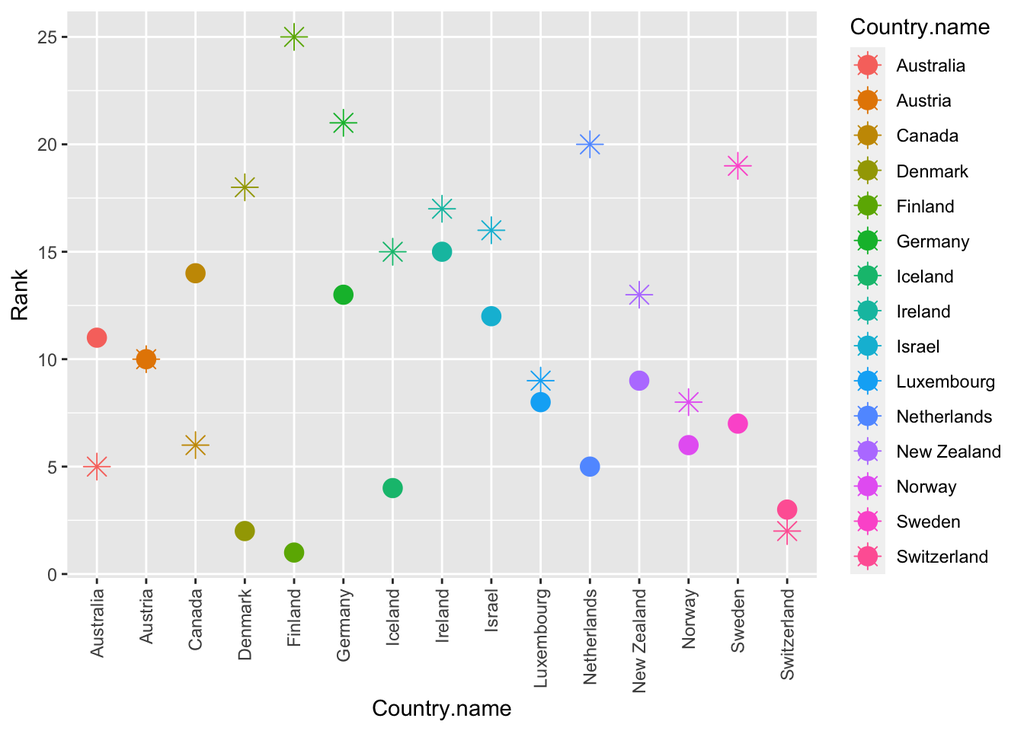

```r
actual <- subset(happy.covid, select=c(Country.name, Ladder.score ))
colnames(actual)[2] <- "Score"
actual <- actual[order(-actual$Score),]
actual$Rank <- 1:nrow(actual)
actual <- actual[1:15, ]

lm_predicted <- subset(happy.covid, select=c(Country.name, lm.pred.score))
lm_predicted <- lm_predicted[order(-lm_predicted$lm.pred.score),]
lm_predicted$lm_Rank <- 1:nrow(lm_predicted)

glm_predicted <- subset(happy.covid, select=c(Country.name, glm.pred.score))
glm_predicted <- glm_predicted[order(-glm_predicted$glm.pred.score),]
glm_predicted$glm_Rank <- 1:nrow(glm_predicted)

results <- actual %>% inner_join(lm_predicted, by = "Country.name")
results <- results %>% inner_join(glm_predicted, by = "Country.name")

ggplot(results, aes(x=Country.name, colour=Country.name)) +
geom_point( aes(y=Rank), size=4) +
geom_point( aes(y=lm_Rank), size=4, shape=3) +
geom_point( aes(y=glm_Rank), size=4, shape=4) +
theme(axis.text.x = element_text(angle = 90, vjust = 0.5, hjust=1))
```

### Let’s look at the US, Brazil, India, Italy, and China. Countries that had either early or late COVID rates compared to select countries.

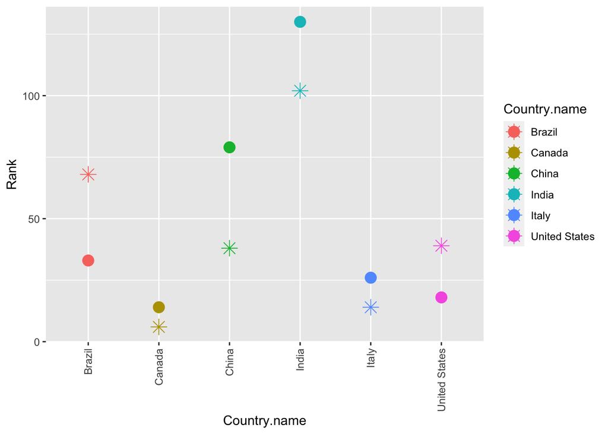

```r
actual <- subset(happy.covid, select=c(Country.name, Ladder.score ))
colnames(actual)[2] <- "Score"
actual <- actual[order(-actual$Score),]
actual$Rank <- 1:nrow(actual)

lm_predicted <- subset(happy.covid, select=c(Country.name, lm.pred.score))
lm_predicted <- lm_predicted[order(-lm_predicted$lm.pred.score),]
lm_predicted$lm_Rank <- 1:nrow(lm_predicted)

glm_predicted <- subset(happy.covid, select=c(Country.name, glm.pred.score))
glm_predicted <- glm_predicted[order(-glm_predicted$glm.pred.score),]
glm_predicted$glm_Rank <- 1:nrow(glm_predicted)

results <- actual %>% inner_join(lm_predicted, by = "Country.name")
results <- results %>% inner_join(glm_predicted, by = "Country.name")
results <- subset(results, Country.name == "Brazil" | Country.name == "United States" | Country.name =="India" | Country.name =="Canada" | Country.name =="China" | Country.name=="Italy", select=c(Country.name, Rank, lm_Rank, glm_Rank))

ggplot(results, aes(x=Country.name, colour=Country.name)) +
geom_point( aes(y=Rank), size=4) +
geom_point( aes(y=lm_Rank), size=4, shape=3) +
geom_point( aes(y=glm_Rank), size=4, shape=4) +
theme(axis.text.x = element_text(angle = 90, vjust = 0.5, hjust=1))
```

## Other Plots and Analysis

#### Q: How did the total deaths caused by COVID-19 correlate with the GDP of a country?

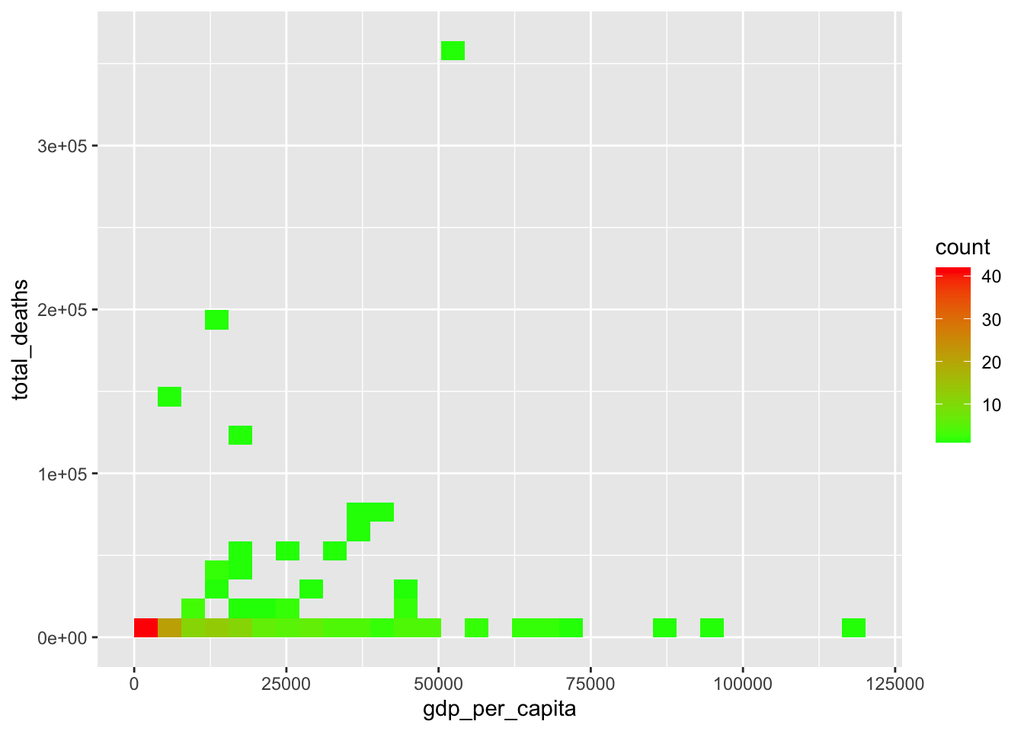

```r
p <- ggplot(covid2020_filtered, aes(gdp_per_capita, total_deaths))
p + geom_bin2d() + scale_fill_gradient(low="green", high="red")
```

#### Q: How did COVID-19 affect happiness ratings in developed countries compared to developing countries?

[figure not shown]

```r
cp <- ggplot(happy.covid, aes(total_deaths, Ladder.score, colour=continent))
cp + geom_point() +
  labs(x="GDP", y="Happiness Score")
```

##### Plot total COVID-19 cases and total deaths of per country, grouped by continent.

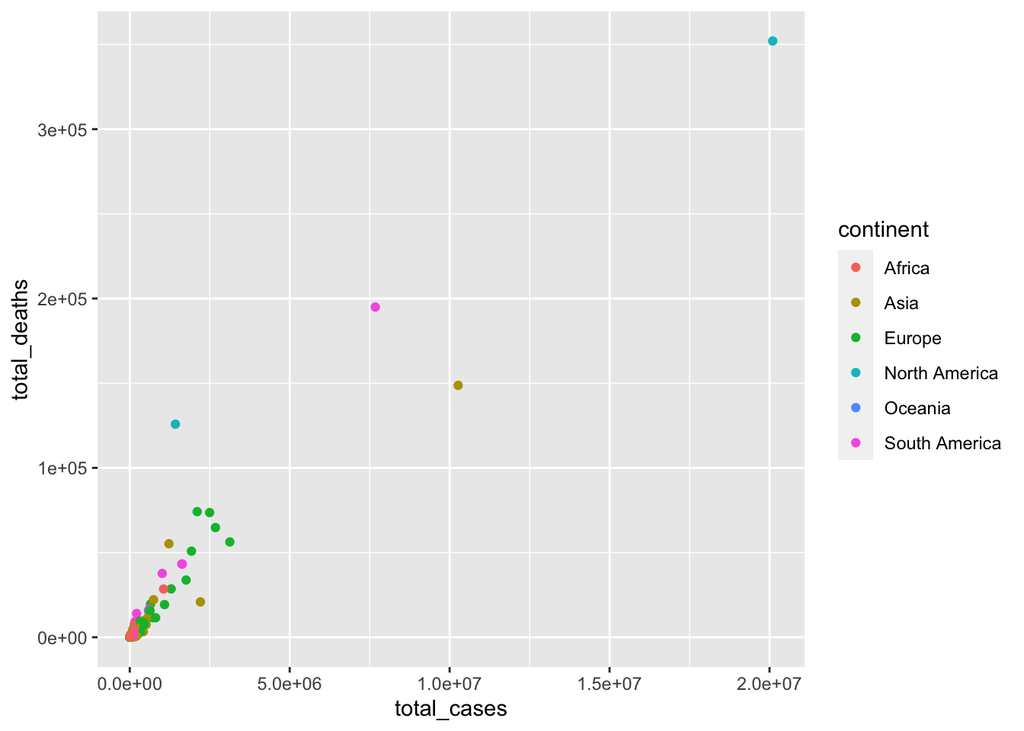

```r
dp <- ggplot(covid2020_filtered, aes(total_cases, total_deaths, colour = continent))
dp + geom_point()
```

# Conclusion

We were surprised by how little it seemed COVID-19 impacted countries or not. For example, in the US, and Brazil ranking seemed to actually improve over the predicted. India seemed to fare a little worse in 2021 than the trend projected. Italy and Canada had predicted and actual values much closer together. The top 15 countries mostly turned out happier than expected. Our models are not accurate enough to make these predictions very confidently. However, this does give us the inkling of a theory that we would like to explore in future projects. Do countries with a higher contribution of healthcare to their happiness score fare better after a pandemic? How did countries with different healthcare systems (socialized medicine vs private, etc.)? Knowing the answers to some of these questions could have a large impact on how countries overhaul and form their healthcare systems in the coming years.

# Impact

Initially, our analysis suggests that the covid pandemic of 2020 had only a small impact on the happiness trends for the world in general. However, when digging into specific countries, we see sometimes dramatic changes in their happiness ranking. This analysis implies that there’s more to the picture, that covid did potentially change certain countries’ happiness trends. We agree with these models and believe that countries that experienced more significant case infection and death rate, or longer and stricter lockdowns, would have a different outlook coming out of the pandemic. For example, if someone’s loved ones passed away, or their business did not survive, these factors would definitely affect their feelings of happiness. There are many other hidden factors that possibly affect people’s happiness implicitly, such as the recuiting freeze for young professors and the extremly low university admission rate towards international students, the borders and customs for many countries have been closed as well, and consequently people cannot travel to see their family or for their careers, etc. These factors are not directly listed in the happiness or covid report, and cannot be used as predictors, but their impact cannot be denied or overlooked. Utilizing our analysis and diving even deeper into some oft hese other potential factors could help countries understand the long-lasting impact on their citizens, to take corrective actions, and importantly, to create new policies for future pandemics.